# Original Study: Data Analysis

Hypothesis 4

```r
animal$factor_prototype_label <- factor(animal$prototype_label)

class(animal$factor_prototype_label)
```

```
## [1] "factor"
```

```r
#multinomial logistic regression model
#by-subject_id varying intercepts and varying
#slope, without slope/intercept correlation
#by-exemplar varying intercept
model_hypo4 <- brm(
  factor_prototype_label ~ trial_type +
    (trial_type || subject_id)+
    (1|exemplar),
  data = animal,
  family = categorical(link = "logit", refcat = NULL)
)

model_hypo4
```

```
##  Family: categorical
##   Links: mucurved = logit; mudCoM = logit; mudCoM2 = logit; mustraight = logit
## Formula: factor_prototype_label ~ trial_type + (trial_type || subject_id) + (1 | exemplar)
##    Data: animal (Number of observations: 598)
## Samples: 4 chains, each with iter = 2000; warmup = 1000; thin = 1;
##          total post-warmup samples = 4000
##
## Group-Level Effects:
## ~exemplar (Number of levels: 15)
##                          Estimate Est.Error l-95% CI u-95% CI Rhat Bulk_ESS
## sd(mucurved_Intercept)       0.23      0.18     0.01     0.68 1.00     1920
## sd(mudCoM_Intercept)         0.34      0.24     0.01     0.89 1.00     1314
## sd(mudCoM2_Intercept)        0.69      0.65     0.02     2.42 1.00     3233
## sd(mustraight_Intercept)     0.35      0.19     0.03     0.77 1.00     1313
##                          Tail_ESS
## sd(mucurved_Intercept)       2109
## sd(mudCoM_Intercept)         1314
## sd(mudCoM2_Intercept)        2484
## sd(mustraight_Intercept)     1450
##
## ~subject_id (Number of levels: 53)
##                                  Estimate Est.Error l-95% CI u-95% CI Rhat
## sd(mucurved_Intercept)               2.78      0.58     1.82     4.06 1.01
## sd(mucurved_trial_typeTypical)       1.42      0.70     0.13     2.85 1.01
## sd(mudCoM_Intercept)                 0.56      0.35     0.03     1.33 1.01
## sd(mudCoM_trial_typeTypical)         0.56      0.39     0.03     1.44 1.00
## sd(mudCoM2_Intercept)                0.85      0.70     0.03     2.62 1.00
## sd(mudCoM2_trial_typeTypical)        1.43      1.27     0.06     4.69 1.00
## sd(mustraight_Intercept)             1.01      0.27     0.48     1.57 1.01
## sd(mustraight_trial_typeTypical)     0.59      0.33     0.04     1.26 1.00
##                                  Bulk_ESS Tail_ESS
## sd(mucurved_Intercept)               1386     2334
## sd(mucurved_trial_typeTypical)        600      908
## sd(mudCoM_Intercept)                  834     1430
## sd(mudCoM_trial_typeTypical)         1004     2056
## sd(mudCoM2_Intercept)                2133     2072
## sd(mudCoM2_trial_typeTypical)        2757     2499
## sd(mustraight_Intercept)             1087     1165
## sd(mustraight_trial_typeTypical)      698     1529
##
```

[output cut: 8 more lines]

```
## mudCoM2_trial_typeTypical       -8.34      6.54   -24.98    -1.90 1.01     1387
## mustraight_trial_typeTypical     0.56      0.42    -0.28     1.39 1.00     2868
##                              Tail_ESS
## mucurved_Intercept               2828
## mudCoM_Intercept                 3302
## mudCoM2_Intercept                3837
## mustraight_Intercept             3017
## mucurved_trial_typeTypical       2130
## mudCoM_trial_typeTypical         2899
## mudCoM2_trial_typeTypical         868
## mustraight_trial_typeTypical     2793
##
## Samples were drawn using sampling(NUTS). For each parameter, Bulk_ESS
## and Tail_ESS are effective sample size measures, and Rhat is the potential
## scale reduction factor on split chains (at convergence, Rhat = 1).
```

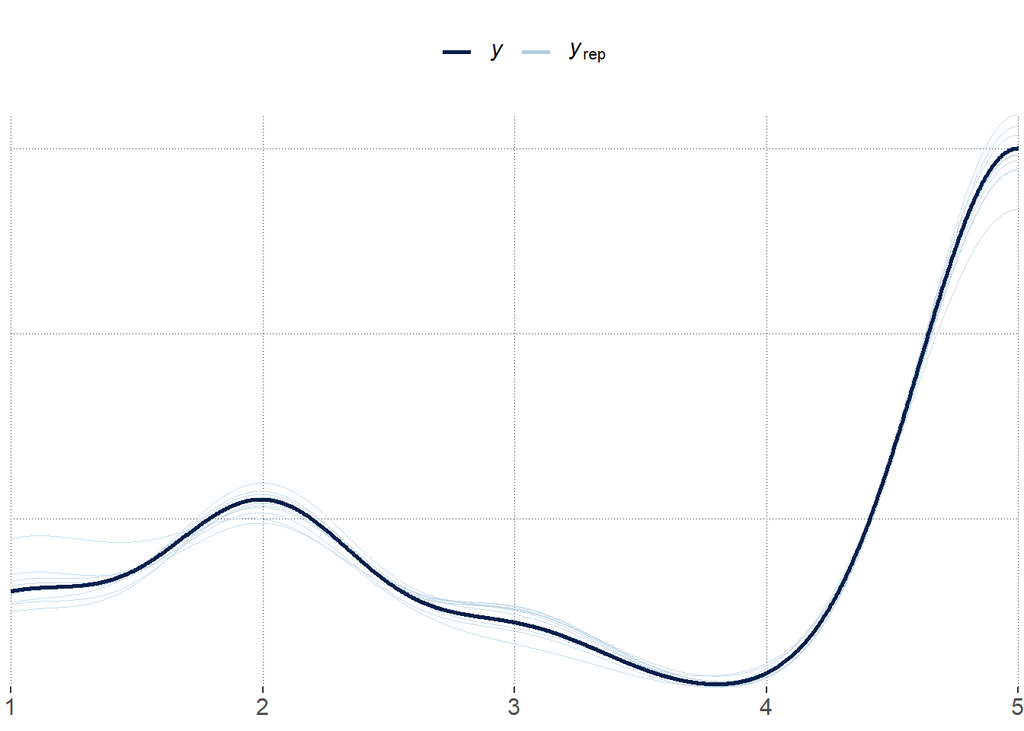

```r
#fitting the model to the actual data
pp_check(model_hypo4)
```

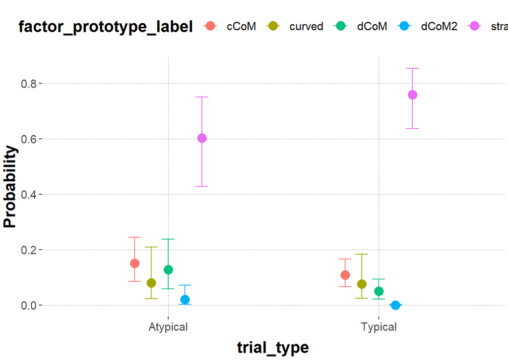

```r
#plotting marginal effects
marginal_effects(model_hypo4, "trial_type", categorical = TRUE)
```

```r
#extracting posteriors
predicted_hypo4 <- model_hypo4 %>%
  spread_draws(b_mucurved_Intercept,
               b_mudCoM_Intercept,
               b_mustraight_Intercept ,
               b_mucurved_trial_typeTypical,
               b_mudCoM_trial_typeTypical,
               b_mustraight_trial_typeTypical) %>%
  # mutating the parameters with their coefficient combination
  mutate(curved_Atypical = plogis(b_mucurved_Intercept),
         curved_Typical = plogis(b_mucurved_Intercept + b_mucurved_trial_typeTypical),
         dCoM_Atypical = plogis(b_mudCoM_Intercept),
          dCoM_Typical = plogis(b_mudCoM_Intercept + b_mudCoM_trial_typeTypical),
         straight_Atypical = plogis(b_mustraight_Intercept),
         straight_Typical = plogis(b_mustraight_Intercept + b_mustraight_trial_typeTypical),
         cCoM_Atypical = plogis(b_mucurved_Intercept + b_mudCoM_Intercept + b_mustraight_Intercept),
         cCoM_Typical = plogis(b_mucurved_Intercept + b_mudCoM_Intercept + b_mustraight_Intercept + b_mucurved_trial_typeTypical +
                             b_mudCoM_trial_typeTypical + b_mustraight_trial_typeTypical)) %>%
  select(curved_Atypical, curved_Typical, dCoM_Atypical, dCoM_Typical, straight_Atypical, straight_Typical, cCoM_Atypical, cCoM_Typical) %>%
  gather(key = "parameter", value = "posterior") %>%
  #muatating categories for cluster and condition for better plotting
   mutate(prototype = ifelse(parameter == "curved_Atypical" | parameter == "curved_Typical",
                        "curved",ifelse(parameter == "dCoM_Atypical"|parameter == "dCoM_Typical", "dcom", ifelse(parameter == "straight_Atypical"|parameter == "straight_Typical", "straight", "cCoM"))),
          trial_type = ifelse(parameter == "curved_Atypical" | parameter == "dCoM_Atypical" | parameter == "straight_Atypical" | parameter == "cCoM_Atypical",
                        "Atypical", "Typical")) %>%
  group_by(prototype, trial_type) %>%
  summarise(mean_posterior = mean(posterior),
            `95lowerCrI` = HDInterval::hdi(posterior, credMass = 0.90)[1],
            `95higherCrI` = HDInterval::hdi(posterior, credMass = 0.90)[2])

predicted_hypo4
```

```
## # A tibble: 8 x 5
## # Groups:   prototype [4]
##   prototype trial_type mean_posterior `95lowerCrI` `95higherCrI`
##   <chr>     <chr>               <dbl>        <dbl>         <dbl>
## 1 cCoM      Atypical            0.612        0.295         0.935
## 2 cCoM      Typical             0.658        0.391         0.912
## 3 curved    Atypical            0.356        0.137         0.562
## 4 curved    Typical             0.409        0.184         0.607
## 5 dcom      Atypical            0.459        0.294         0.626
## 6 dcom      Typical             0.316        0.184         0.429
## 7 straight  Atypical            0.792        0.699         0.889
## 8 straight  Typical             0.871        0.823         0.923
```

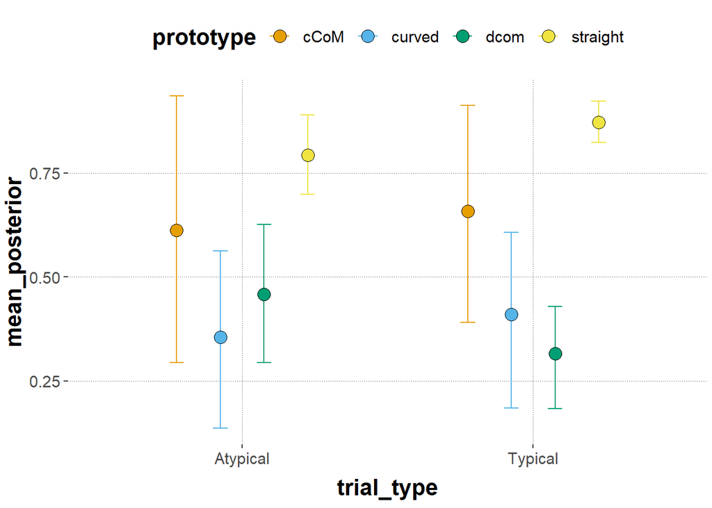

```r
#plotting mean posterior probability of every prototype for each trial type
ggplot(predicted_hypo4) +
   geom_errorbar(aes(x = trial_type, y = mean_posterior, color = prototype,
                    ymin = `95lowerCrI`, ymax = `95higherCrI`),
                width = 0.2,  position = position_dodge(width = 0.6)) +
  geom_point(aes(x = trial_type, y = mean_posterior, fill = prototype),
             size = 4, pch = 21, color = "black", position = position_dodge(0.6))
```

Results: The graph indicates the mean posterior probabilities of the prototypes for the Atypical and the Typical condition. Taking from the graph there are no big differences between the prototype occuerences of trial types. The dCoM prototype mean posterior probability is higher for Atypical than Typical trials. Overall no noteworthy influence of the experimental condition can be seen on the likelihood of obtaining different amounts of prototypes.

Hypothese 5

```r
animal$RT_log <- log(animal$RT)
animal$RT_log_s = my_scale(animal$RT_log)

#informative priors
prior_hypo5 <- c(
  #priors for all fixed effects (trial_type)
  set_prior("student_t(3, 0, 2)", class = "sigma"),
  #prior for the Intercept
  set_prior("student_t(3, 0, 2)", class = "Intercept"),
  #prior for all SDs including the varying intercepts and slopes
  set_prior("student_t(3, 0, 2)", class = "sd")
)

#by-subject_id varying intercepts and varying
#slope, without slope/intercept correlation
#by-exemplar varying intercept
model_hypo5 = brm(
  RT_log_s ~ trial_type +
    (trial_type || subject_id)+
    (1 |exemplar),
  control=list(adapt_delta=0.99, max_treedepth=15),
  data = animal,
  prior = prior_hypo5
  )


model_hypo5
```

```
##  Family: gaussian
##   Links: mu = identity; sigma = identity
## Formula: RT_log_s ~ trial_type + (trial_type || subject_id) + (1 | exemplar)
##    Data: animal (Number of observations: 598)
## Samples: 4 chains, each with iter = 2000; warmup = 1000; thin = 1;
##          total post-warmup samples = 4000
##
## Group-Level Effects:
## ~exemplar (Number of levels: 15)
##               Estimate Est.Error l-95% CI u-95% CI Rhat Bulk_ESS Tail_ESS
## sd(Intercept)     0.16      0.05     0.08     0.27 1.00     1208     1695
##
## ~subject_id (Number of levels: 53)
##                       Estimate Est.Error l-95% CI u-95% CI Rhat Bulk_ESS
## sd(Intercept)             0.82      0.08     0.67     1.00 1.01      503
## sd(trial_typeTypical)     0.09      0.06     0.00     0.25 1.01      528
##                       Tail_ESS
## sd(Intercept)             1455
## sd(trial_typeTypical)     1118
##
## Population-Level Effects:
##                   Estimate Est.Error l-95% CI u-95% CI Rhat Bulk_ESS Tail_ESS
## Intercept             0.30      0.14     0.02     0.59 1.00      613     1295
## trial_typeTypical    -0.37      0.11    -0.58    -0.15 1.00     1900     2308
##
## Family Specific Parameters:
##       Estimate Est.Error l-95% CI u-95% CI Rhat Bulk_ESS Tail_ESS
## sigma     0.59      0.02     0.56     0.63 1.00     3947     2832
##
## Samples were drawn using sampling(NUTS). For each parameter, Bulk_ESS
## and Tail_ESS are effective sample size measures, and Rhat is the potential
## scale reduction factor on split chains (at convergence, Rhat = 1).
```

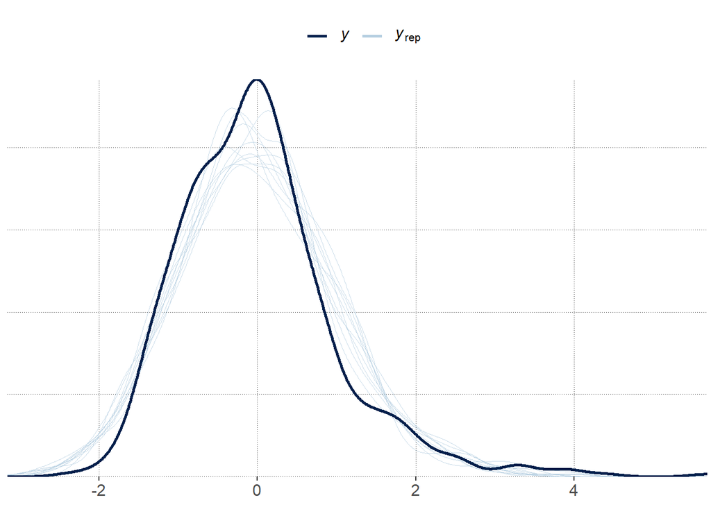

```r
#fitting the model to the actual data
pp_check(model_hypo5)
```